# R basic

KimHyein

2018/12/03

## 1. Vector/Array

Arrays can store only data type.

### [Including Code]

```r
a = c(1,3,5,7,9)
b = c('Kim','Lee','Michael','Lee')

#Get the first element
a[1]
```

```
## [1] 1
```

```r
a[2:5]
```

```
## [1] 3 5 7 9
```

```r
length(a)
```

```
## [1] 5
```

```r
sum(a)
```

```
## [1] 25
```

```r
mean(a)
```

```
## [1] 5
```

```r
a+1
```

```
## [1]  2  4  6  8 10
```

```r
#Compare elements
a==3
```

```
## [1] FALSE  TRUE FALSE FALSE FALSE
```

```r
#Find the index
which(a==5)
```

```
## [1] 3
```

```r
#Get the element with an index
a[which(a==5)]
```

```
## [1] 5
```

```r
which(b=='Lee')
```

```
## [1] 2 4
```

```r
#Count the matched
length(which(b=='Lee'))
```

```
## [1] 2
```

## 2. List

A list is an R structure that may contain objects of any other types, including other lists. List items need to be pointed by [[index]] (double square brackets) ‘List’ can make tree-like data

### [Including Code]

```r
#List
L = list(ids=1:5, whos=c('Kim','Lee','Choi'))

names(L)
```

```
## [1] "ids"  "whos"
```

```r
L[[1]]
```

```
## [1] 1 2 3 4 5
```

```r
L$ids
```

```
## [1] 1 2 3 4 5
```

```r
L$whos
```

```
## [1] "Kim"  "Lee"  "Choi"
```

```r
L$whos[1]
```

```
## [1] "Kim"
```

```r
L[[1]][5]
```

```
## [1] 5
```

## 3. DataFrame

A data frame is a table or a two-dimensional array-like structure in which each column contains values of one variable and each row contains one set of values from each column

### [Including Code]

```r
last_name = c('lee','kim','choi','park','lee')
age = c(24,30,50,34,12)
gender = c('M','F','M','M','M')

last_name
```

```
## [1] "lee"  "kim"  "choi" "park" "lee"
```

```r
age
```

```
## [1] 24 30 50 34 12
```

```r
gender
```

```
## [1] "M" "F" "M" "M" "M"
```

```r
#create dataframe
person = data.frame(last_name,age,gender)
person
```

```
##   last_name age gender
## 1       lee  24      M
## 2       kim  30      F
## 3      choi  50      M
## 4      park  34      M
## 5       lee  12      M
```

```r
person$last_name
```

```
## [1] lee  kim  choi park lee
## Levels: choi kim lee park
```

```r
person$age
```

```
## [1] 24 30 50 34 12
```

```r
person$gender
```

```
## [1] M F M M M
## Levels: F M
```

```r
person[3,2]
```

```
## [1] 50
```

```r
person[3,1:3]
```

```
##   last_name age gender
## 3      choi  50      M
```

```r
person[3,]
```

```
##   last_name age gender
## 3      choi  50      M
```

```r
person[3,]$age
```

```
## [1] 50
```

```r
person[3,'age']
```

```
## [1] 50
```

```r
person$last_name=='choi'
```

```
## [1] FALSE FALSE  TRUE FALSE FALSE
```

```r
which(person$last_name=='choi')
```

```
## [1] 3
```

```r
person[which(person$last_name=='choi'),]
```

```
##   last_name age gender
## 3      choi  50      M
```

```r
person$age==12
```

```
## [1] FALSE FALSE FALSE FALSE  TRUE
```

```r
which(person$age==12)
```

```
## [1] 5
```

```r
person[which(person$age==12),]
```

```
##   last_name age gender
## 5       lee  12      M
```

```r
person[which(person$age>=30),]
```

```
##   last_name age gender
## 2       kim  30      F
## 3      choi  50      M
## 4      park  34      M
```

```r
person[which(person$gender=='M'),]
```

```
##   last_name age gender
## 1       lee  24      M
## 3      choi  50      M
## 4      park  34      M
## 5       lee  12      M
```

```r
#nrow => row count
nrow(person[which(person$gender=='M'),])
```

```
## [1] 4
```

```r
#length => column count
length(person[which(person$gender=='M'),])
```

```
## [1] 3
```

```r
person[which(person$gender=='M'& person$age<=30),]
```

```
##   last_name age gender
## 1       lee  24      M
## 5       lee  12      M
```

```r
person[which(person$gender=='M'| person$age<=30),]
```

```
##   last_name age gender
## 1       lee  24      M
## 2       kim  30      F
## 3      choi  50      M
## 4      park  34      M
## 5       lee  12      M
```

## 4. Matrix

### [Including Code]

```r
matrix(1:12,nrow=3,byrow=FALSE)
```

```
##      [,1] [,2] [,3] [,4]
## [1,]    1    4    7   10
## [2,]    2    5    8   11
## [3,]    3    6    9   12
```

```r
matrix(1:12,nrow=3,byrow=TRUE)
```

```
##      [,1] [,2] [,3] [,4]
## [1,]    1    2    3    4
## [2,]    5    6    7    8
## [3,]    9   10   11   12
```

```r
A = matrix(1:12,nrow=3,byrow=TRUE)
A
```

```
##      [,1] [,2] [,3] [,4]
## [1,]    1    2    3    4
## [2,]    5    6    7    8
## [3,]    9   10   11   12
```

```r
A[2,3]
```

```
## [1] 7
```

```r
A[1:2,3:4]
```

```
##      [,1] [,2]
## [1,]    3    4
## [2,]    7    8
```

```r
t(A)
```

```
##      [,1] [,2] [,3]
## [1,]    1    5    9
## [2,]    2    6   10
## [3,]    3    7   11
## [4,]    4    8   12
```

## 5. Json

(Data Expression Sharing)

JSON: JavaScript Object Notation

JSON is a syntax for storing and exchanging data. JSON is text, written with javascript obect notation.

### [Including Code]

```r
item1 = list(name='Lee',age=35)
item2 = list(name='Kim',age=25)
item3 = list(name='Smith',age=40)

members = list(item1,item2,item3)

library(rjson)

toJSON(members)
```

```
## [1] "[{\"name\":\"Lee\",\"age\":35},{\"name\":\"Kim\",\"age\":25},{\"name\":\"Smith\",\"age\":40}]"
```

```r
con = file('test.json')

writeLines(toJSON(members),con)

group = fromJSON(file='test.json')

all.equal(members,group)
```

```
## [1] TRUE
```

## 6. Function

One of the great strengths of R is the user’s ability to add functions. The structure of a function is given below.

myfunction <- function(arg1, arg2, …){

statements

return(object)

}

### [Including Code]

```r
myfunc = function(a,b) {return(a+b)}
myfunc(1,2)
```

```
## [1] 3
```

```r
myfunc = function(a,b,c=100) {return(a+b+c)}
myfunc(1,2)
```

```
## [1] 103
```

```r
myfunc(1,2,1000)
```

```
## [1] 1003
```

```r
myfunc = function(a) {if(a==1) TRUE else FALSE}
myfunc
```

```
## function(a) {if(a==1) TRUE else FALSE}
```

```r
myfunc(1)
```

```
## [1] TRUE
```

```r
myfunc(2)
```

```
## [1] FALSE
```

```r
b = c(1:5)
b
```

```
## [1] 1 2 3 4 5
```

```r
for(i in b) {print(myfunc(i))}
```

```
## [1] TRUE
## [1] FALSE
## [1] FALSE
## [1] FALSE
## [1] FALSE
```

## 7. Save

save: writes an external representation of R objects to the specified file.

### [Including Code]

```r
a = c(1:100)
a
```

```
##   [1]   1   2   3   4   5   6   7   8   9  10  11  12  13  14  15  16  17
##  [18]  18  19  20  21  22  23  24  25  26  27  28  29  30  31  32  33  34
##  [35]  35  36  37  38  39  40  41  42  43  44  45  46  47  48  49  50  51
##  [52]  52  53  54  55  56  57  58  59  60  61  62  63  64  65  66  67  68
##  [69]  69  70  71  72  73  74  75  76  77  78  79  80  81  82  83  84  85
##  [86]  86  87  88  89  90  91  92  93  94  95  96  97  98  99 100
```

```r
save(a,file='a_save.RData')

remove(a)

#>a
#Error: object 'a' not found

load(file='a_save.RData')
a
```

```
##   [1]   1   2   3   4   5   6   7   8   9  10  11  12  13  14  15  16  17
##  [18]  18  19  20  21  22  23  24  25  26  27  28  29  30  31  32  33  34
##  [35]  35  36  37  38  39  40  41  42  43  44  45  46  47  48  49  50  51
##  [52]  52  53  54  55  56  57  58  59  60  61  62  63  64  65  66  67  68
##  [69]  69  70  71  72  73  74  75  76  77  78  79  80  81  82  83  84  85
##  [86]  86  87  88  89  90  91  92  93  94  95  96  97  98  99 100
```

## 8. Apply

returns a vector or array or list of values obtained by applying a function to margins of an array or matrix.

lapply returns a list of the same length as X, each element of which is the result of applying FUN to the corresponding element of X.

apply(X, MARGIN, FUN, …)

MARGIN: 1-> Row way, 2-> Column way

### [Including Code]

```r
x = cbind(x1 = 3,x2 = c(4:1,2:5))
dimnames(x)[[1]] <- letters[1:8]
x
```

```
##   x1 x2
## a  3  4
## b  3  3
## c  3  2
## d  3  1
## e  3  2
## f  3  3
## g  3  4
## h  3  5
```

```r
apply(x,1,mean,trim=.2)
```

```
##   a   b   c   d   e   f   g   h
## 3.5 3.0 2.5 2.0 2.5 3.0 3.5 4.0
```

```r
apply(x,2,mean,trim=.2)
```

```
## x1 x2
##  3  3
```

```r
lapply(c(1:3),function(x) {x+100})
```

```
## [[1]]
## [1] 101
##
## [[2]]
## [1] 102
##
## [[3]]
## [1] 103
```

```r
y = cbind(x1 = 3,x2 = c(4:1,2:5))
y
```

```
##      x1 x2
## [1,]  3  4
## [2,]  3  3
## [3,]  3  2
## [4,]  3  1
## [5,]  3  2
## [6,]  3  3
## [7,]  3  4
## [8,]  3  5
```

```r
dimnames(y)[[1]] <- letters[1:8]
y
```

```
##   x1 x2
## a  3  4
## b  3  3
## c  3  2
## d  3  1
## e  3  2
## f  3  3
## g  3  4
## h  3  5
```

```r
dimnames(y)[[2]] <- letters[9:10]
y
```

```
##   i j
## a 3 4
## b 3 3
## c 3 2
## d 3 1
## e 3 2
## f 3 3
## g 3 4
## h 3 5
```

```r
z = c(x1 = 3, x2 = 5)
z
```

```
## x1 x2
##  3  5
```

```r
z = cbind(x1 = 3, x2 = 5)
z
```

```
##      x1 x2
## [1,]  3  5
```

```r
z = c(x1 = 3, x2 = c(1:5))
z
```

```
##  x1 x21 x22 x23 x24 x25
##   3   1   2   3   4   5
```

```r
z = cbind(x1 =3, x2 = c(1:5))
z
```

```
##      x1 x2
## [1,]  3  1
## [2,]  3  2
## [3,]  3  3
## [4,]  3  4
## [5,]  3  5
```

## 9. Plot

### [Including Code]

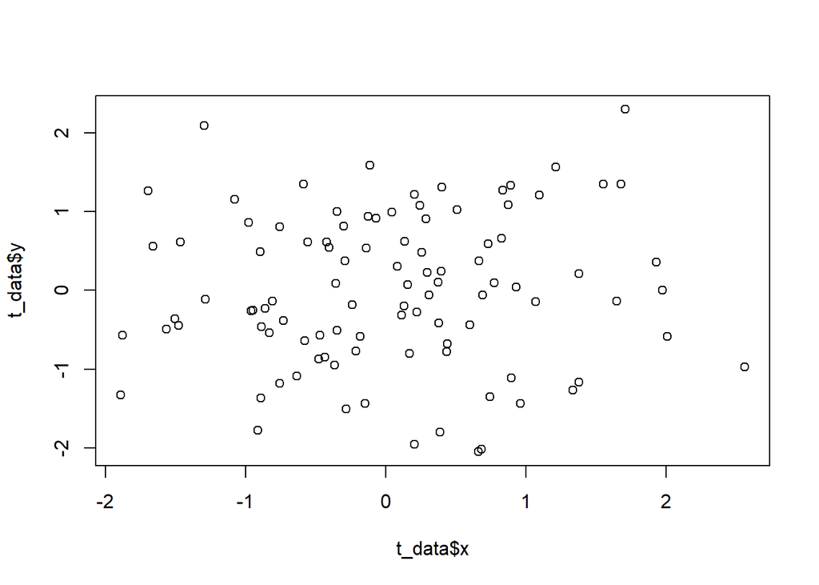

```r
x = rnorm(100)
y = rnorm(100)
t_data = data.frame(x,y)
plot(t_data$x,t_data$y)
```

```r
t_data$x
```

```
##   [1]  0.38048272  0.16955936 -1.69710482  1.68010535  0.08329268
##   [6]  0.73175214 -0.28988628 -0.55596424  1.70908327  2.01072956
##  [11]  0.25516252  0.89287743 -1.50330498 -0.43234593  0.40032188
##  [16]  1.37974199 -0.14841950 -0.88774010  1.97372096 -0.75584065
##  [21]  0.15828055 -0.36573426 -1.56746825  0.20505197  0.74296329
##  [26]  0.39822624  0.44065944  0.82670089 -0.57662188 -0.89246737
##  [31]  0.60111603  0.96250260 -1.29533193 -0.23934185  1.64913486
##  [36]  1.37972450 -0.81030559 -0.11344364 -0.75618771  1.07066249
##  [41] -1.46660702  0.68358587 -0.82953599 -0.63516965 -0.86262623
##  [46] -0.29813133  0.37694048  0.04379186  1.93139514 -0.42186166
##  [51]  0.29660706 -0.34561007 -0.97637005 -0.18257128  0.20714384
##  [56]  0.93147018  1.21388545 -0.95975498  0.13410585  1.33488413
##  [61] -0.94713556 -1.66136232  0.77460812 -1.07962241 -0.58679075
##  [66]  2.56279821 -1.47810065 -0.12355775  1.55209562 -1.87758490
##  [71]  0.87463145 -0.28155769 -0.34939603  0.83400895  1.09716630
##  [76]  0.66553851 -0.91310616 -1.89243703  0.30882909 -0.89359258
##  [81]  0.89763688  0.38640809  0.69181810  0.43374314  0.13326325
##  [86] -0.46893694 -0.35412886 -0.06999956 -0.47797969  0.24587962
##  [91] -0.21138457  0.66396348 -0.13707427  0.11293806 -0.40615228
##  [96]  0.28906671 -1.28626393 -0.72843202  0.22152796  0.51036583
```

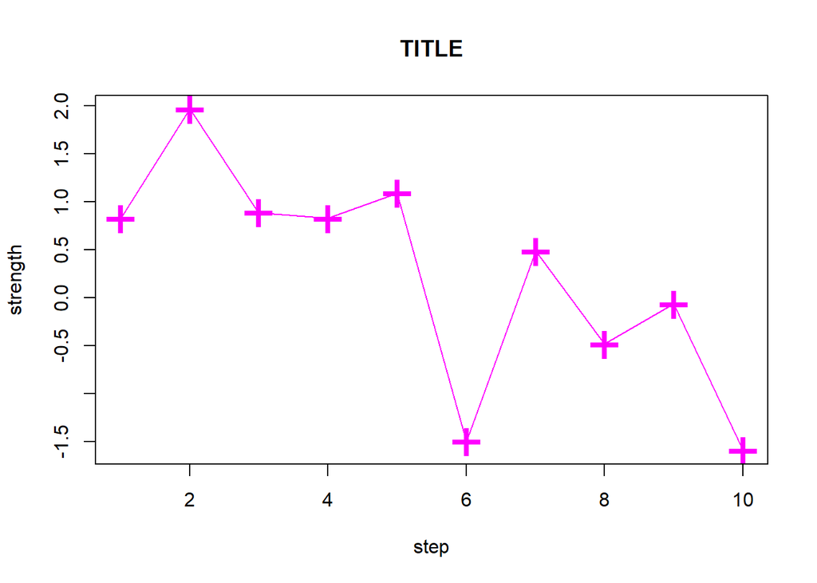

```r
View(t_data)

plot(rnorm(10),type='o',xlab='step',ylab='strength',col='#FF00FF',pch='+',cex=3,main='TITLE')
```

## 10. ggPlot

### [Including Code]

```r
library(ggplot2)

test_data = data.frame(step=1:100,value=abs(rnorm(100)))
head(test_data)
```

```
##   step       value
## 1    1 0.677085896
## 2    2 0.796407837
## 3    3 0.362141099
## 4    4 1.040621830
## 5    5 0.005186509
## 6    6 0.704415705
```

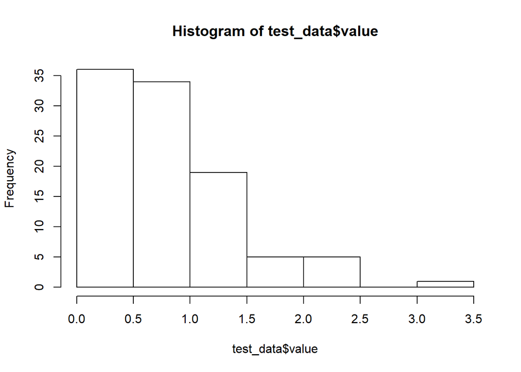

```r
hist(test_data$value)
```

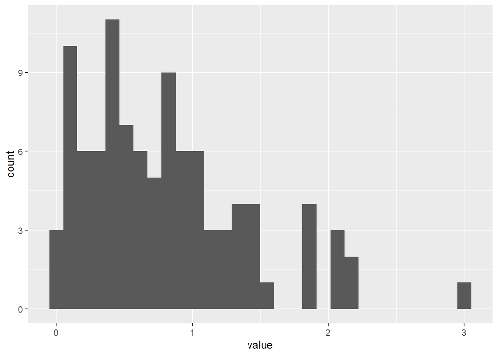

```r
ggplot(test_data,aes(x=value))+geom_histogram()
```

## 11. 3DPlot

### [Including Code]

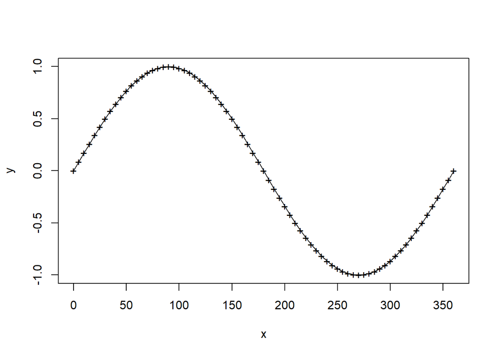

```r
#0,5,10,,,360
x = seq(0,360,by=5)

#radian value change
y = sin(x*pi/180)

plot(x,y,type='o',pch='+')
```

```r
library(rgl)

plot3d(rnorm(100),rnorm(100),rnorm(100))
test_data = data.frame(x=rnorm(100),y=rnorm(100),z=rnorm(100))
plot3d(test_data)
head(test_data)
```

```
##            x          y          z
## 1 -0.4034828  1.2915066 -1.2693690
## 2 -2.2936411 -0.8660113  0.5598954
## 3 -0.2131388  0.3368339  0.3330266
## 4  0.1427311  0.1952335  1.0400611
## 5 -0.8902318  0.8748538 -0.4198883
## 6 -0.2211977 -0.2751247  2.2335713
```

```r
plot3d(NULL,xlab='')
r=10
for (p in seq(0,180,10)) {
  q = seq(0,360,10)
  x = r *sin(p*pi/180)*cos(q*pi/180)
  y = r *sin(p*pi/180)*sin(q*pi/180)
  z = r *cos(p*pi/180)
  points3d(x,y,z)
  lines3d(x,y,z,col='red')
}
```

## 12. Map

### [Including Code]

```r
library(ggplot2)
library(ggmap)
library(maps)
library(mapdata)

map_data
```

```
## function (map, region = ".", exact = FALSE, ...)
## {
##     try_require("maps", "map_data")
##     map_obj <- maps::map(map, region, exact = exact, plot = FALSE,
##         fill = TRUE, ...)
##     fortify(map_obj)
## }
## <bytecode: 0x000000001768a1c0>
## <environment: namespace:ggplot2>
```

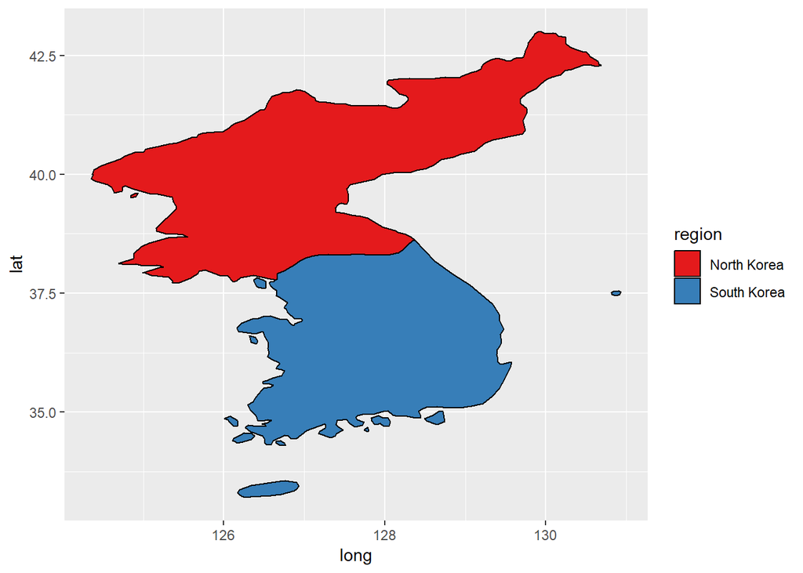

```r
asia = map_data("world",region=c("South Korea","North Korea"))

g = ggplot(asia,aes(x=long,y=lat,group=group,fill=region)) +
  geom_polygon(colour="black") +
  scale_fill_brewer(palette="Set1")

plot(g)
```

```r
head(asia)
```

```
##       long      lat group order      region subregion
## 1 126.3270 33.22363     1     1 South Korea  Cheju Do
## 2 126.2820 33.20151     1     2 South Korea  Cheju Do
## 3 126.2402 33.21484     1     3 South Korea  Cheju Do
## 4 126.2290 33.22524     1     4 South Korea  Cheju Do
## 5 126.1787 33.28257     1     5 South Korea  Cheju Do
## 6 126.1656 33.31201     1     6 South Korea  Cheju Do
```

```r
tail(asia)
```

```
##         long      lat group order      region subregion
## 524 130.2467 42.74482    13   524 North Korea      <NA>
## 525 130.2956 42.68496    13   525 North Korea      <NA>
## 526 130.3607 42.63086    13   526 North Korea      <NA>
## 527 130.4503 42.58169    13   527 North Korea      <NA>
## 528 130.4982 42.57051    13   528 North Korea      <NA>
## 529 130.5269 42.53540    13   529 North Korea      <NA>
```

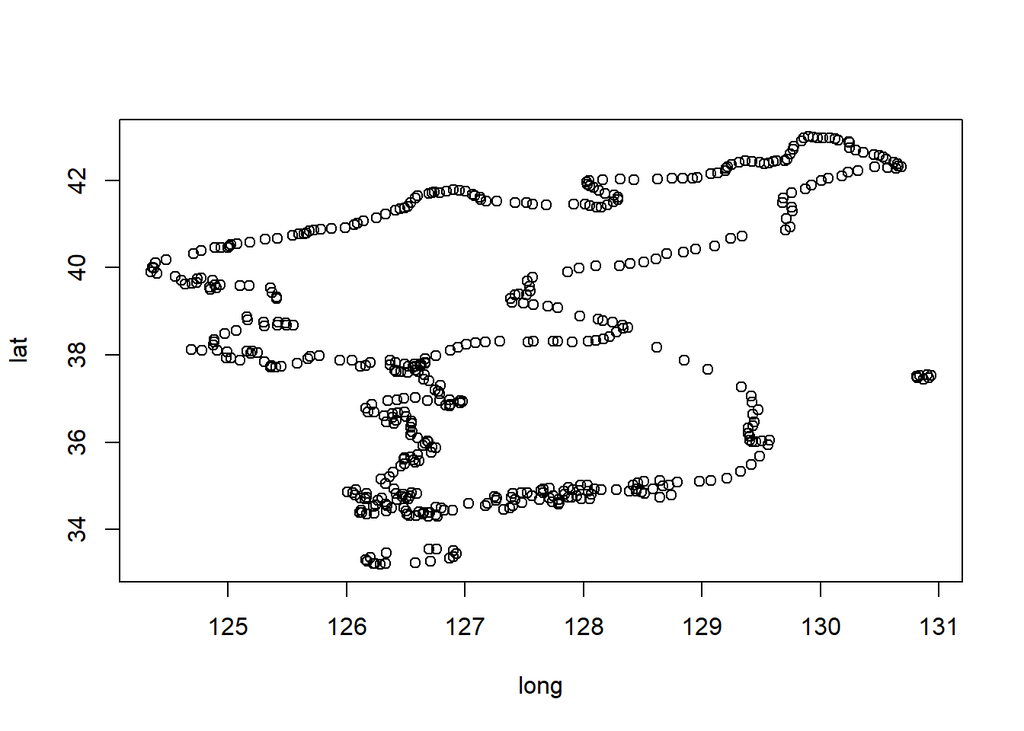

```r
plot(asia[,c('long','lat')])
```

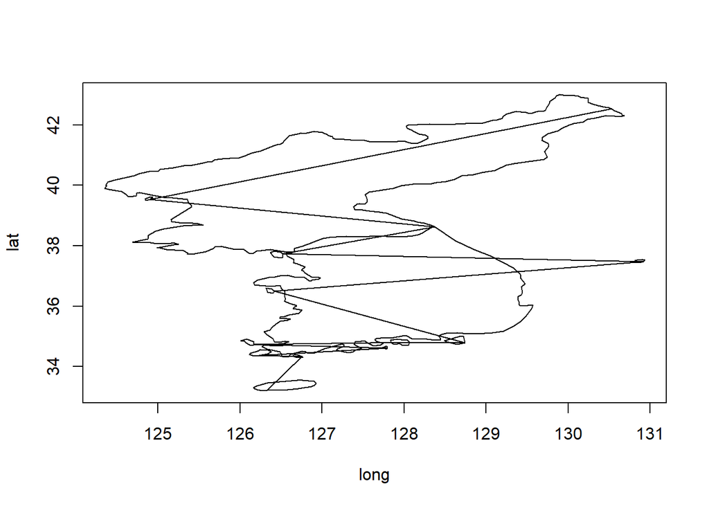

```r
plot(asia[,c('long','lat')],type='l')
```

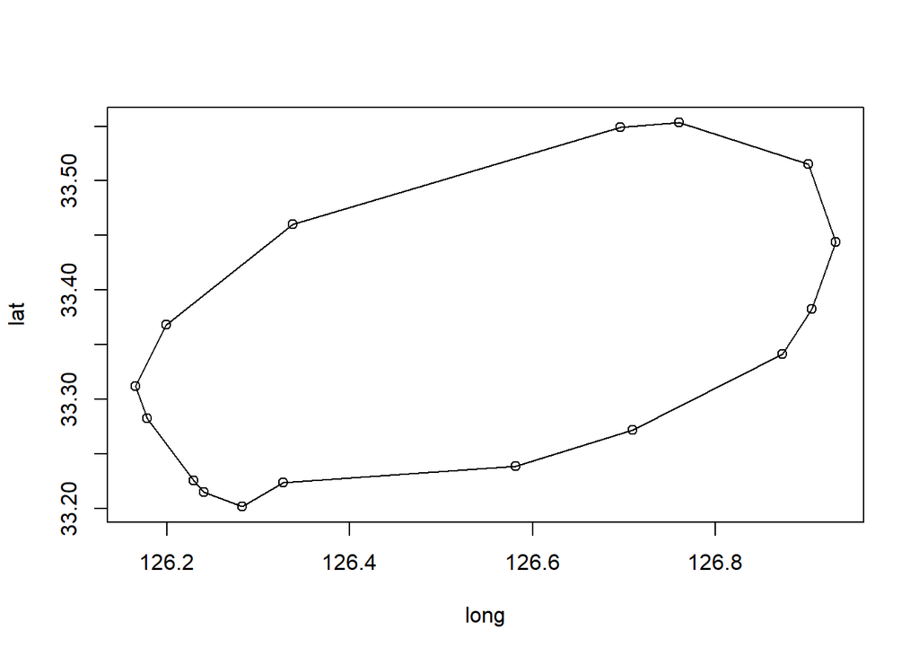

```r
plot(asia[asia$subregion=='Cheju Do',c('long','lat')],type='o')
```

## 13. googlemap [not running]

### [Including Code]

library(ggmap) library(ggplot2) library(maps) library(mapdata)

g_map = get_map( location = c(lon = 127.102773, lat = 37.512423), color = “color”, source = “google”, maptype = “roadmap”, zoom = 16)

ggmap(g_map, extent = “device”, ylab = “Latitude”, xlab = “Longitude”)

ourPosition = data.frame(lon=127.102773, lat = 37.512423)

ggmap(g_map) + geom_point(data=ourPosition,aes(x=lon,y=lat), shape=9,color=‘red’,size=5) + geom_text(data=ourPosition,aes(x=lon,y=(lat)), color=‘red’,label=‘We are here!’,vjust=1.8)

> ERROR MASSAGE

cannot open URL ‘http://maps.googleapis.com/maps/api/staticmap?center=37.512423,127.102773&zoom=16&size=640x640&scale=2&maptype=roadmap&language=en-EN&sensor=false’: HTTP status was ‘403 Forbidden’Error in download.file(url, destfile = tmp, quiet = !messaging, mode = “wb”) : cannot open URL ’http://maps.googleapis.com/maps/api/staticmap?center=37.512423,127.102773&zoom=16&size=640x640&scale=2&maptype=roadmap&language=en-EN&sensor=false’

## 14. Linear_Regression

### [Including Code]

```r
head(airquality)
```

```
##   Ozone Solar.R Wind Temp Month Day
## 1    41     190  7.4   67     5   1
## 2    36     118  8.0   72     5   2
## 3    12     149 12.6   74     5   3
## 4    18     313 11.5   62     5   4
## 5    NA      NA 14.3   56     5   5
## 6    28      NA 14.9   66     5   6
```

```r
tail(airquality)
```

```
##     Ozone Solar.R Wind Temp Month Day
## 148    14      20 16.6   63     9  25
## 149    30     193  6.9   70     9  26
## 150    NA     145 13.2   77     9  27
## 151    14     191 14.3   75     9  28
## 152    18     131  8.0   76     9  29
## 153    20     223 11.5   68     9  30
```

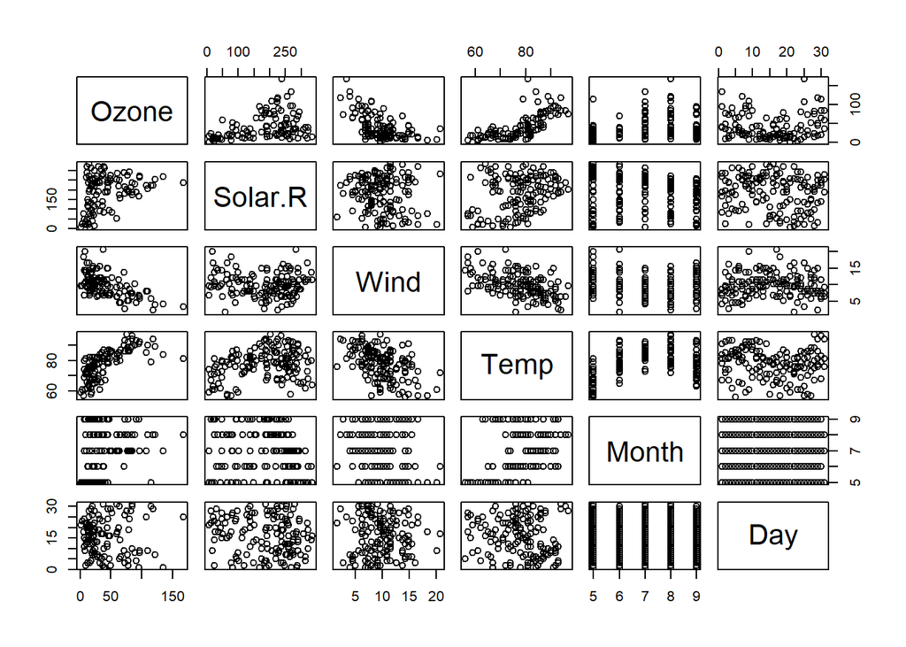

```r
plot(airquality)
```

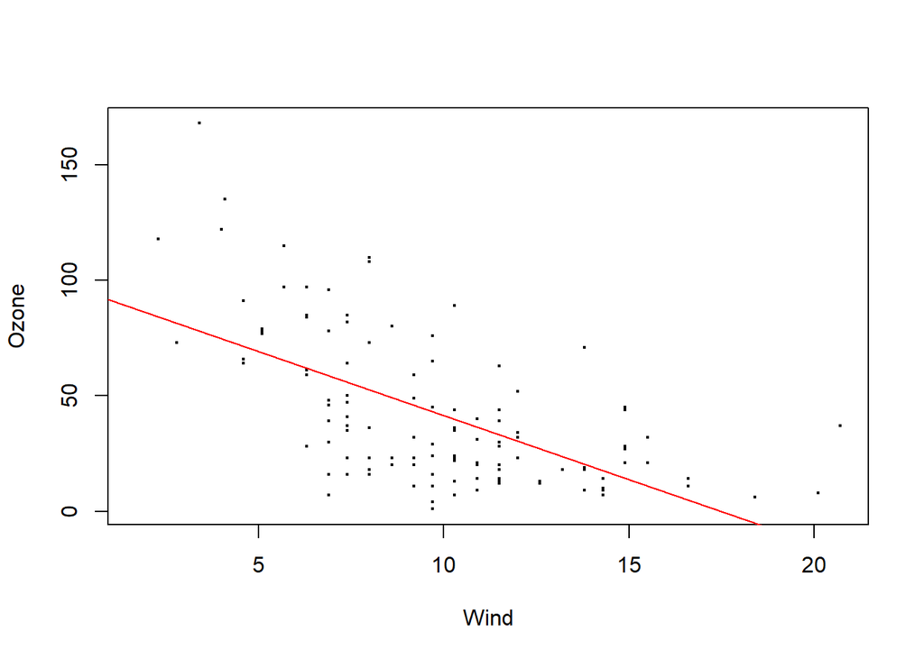

```r
res = lm(formula = Ozone ~ Wind, data=airquality)
plot(airquality[,c('Wind','Ozone')],cex=0.3)
abline(res,col='red')
```

## 15. Clustering

### [Including Code]

```r
num_of_clusters=5
num_of_elements=200

x = sample(1:1000,num_of_elements,replace=F)
y = sample(1:1000,num_of_elements,replace=F)

t_data = data.frame(x=x,y=y)
head(t_data)
```

```
##     x   y
## 1 426 434
## 2 345 169
## 3  65 999
## 4 795 224
## 5 972 869
## 6 256 796
```

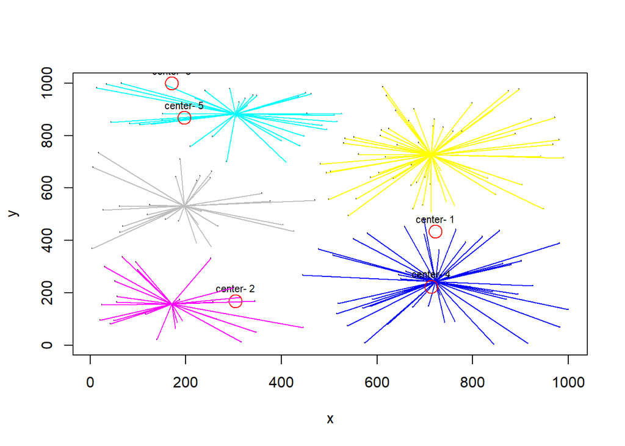

```r
plot(x,y,cex=0.1)

res = kmeans(t_data,num_of_clusters)

for (i in 1:num_of_clusters) {
  for (j in which(res$cluster==i)) {
  lines(c(res$centers[i,1],t_data[j,1]),
       c(res$centers[i,2],t_data[j,2]),
       col=i+3)
}
  points(res$centers[i,1],t_data[i,2], col='red',cex=2)

  text(res$centers[i,1],t_data[i,2],labels=paste('center-',i),pos=3,cex=0.7)

}
```